# I/ Descriptive analysis

# 2/ ACP Method

```python
import pandas as pd
df = pd.read_csv('serviceUtiliseParClient.csv')
df.head()
```

|  | Nombre | mp_numero | Service |
| --- | --- | --- | --- |
| 0 | 1 | 12668958926 | Mobiflouss |
| 1 | 2 | 21268958926 | Mobiflouss |
| 2 | 1 | 21600000088 | Mobicash |
| 3 | 1 | 21600667546 | Mobicash |
| 4 | 1 | 21604402745 | Mobicash |

```python
df.describe()
```

|  | Nombre | mp_numero |
| --- | --- | --- |
| count | 29999.000000 | 2.999900e+04 |
| mean | 14.827661 | 2.161253e+10 |
| std | 197.211816 | 5.170178e+07 |
| min | 1.000000 | 1.266896e+10 |
| 25% | 1.000000 | 2.161139e+10 |
| 50% | 3.000000 | 2.161280e+10 |
| 75% | 6.000000 | 2.161440e+10 |
| max | 29639.000000 | 2.161516e+10 |

```python
from sklearn.preprocessing import StandardScaler
features = ['mp_numero', 'Nombre']
# Separating out the features
x = df.loc[:, features].values
# Separating out the target
y = df.loc[:,['Service']].values
# Standardizing the features
x = StandardScaler().fit_transform(x)
```

```python
from sklearn.decomposition import PCA
pca = PCA(n_components=2)
principalComponents = pca.fit_transform(x)
principalDf = pd.DataFrame(data = principalComponents
             , columns = ['Frequency', 'Client'])
```

```python
finalDf = pd.concat([principalDf, df[['Service']]], axis = 1)
```

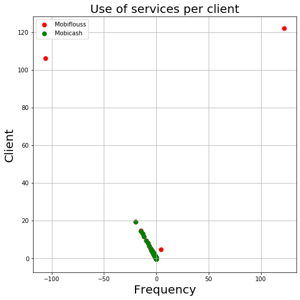

```python
fig = plt.figure(figsize = (8,8))
ax = fig.add_subplot(1,1,1)
ax.set_xlabel('Frequency', fontsize = 20)
ax.set_ylabel('Client', fontsize = 20)
ax.set_title('Use of services per client', fontsize = 20)
targets = ['Mobiflouss', 'Mobicash']
colors = ['r', 'g']
for target, color in zip(targets,colors):
    indicesToKeep = finalDf['Service'] == target
    ax.scatter(finalDf.loc[indicesToKeep, 'Frequency']
               , finalDf.loc[indicesToKeep, 'Client']
               , c = color
               , s = 50)
ax.legend(targets)
ax.grid()
```

Les clients utilisant le service mobicash plus que le service mobiflouss.

```python
pca.explained_variance_ratio_
```

```
array([0.50001484, 0.49998516])
```

```python
import pandas as pd
df = pd.read_csv('serviceUtiliseParOperation.csv')
df.head()
```

|  | Nombre | Service | IdOperation |
| --- | --- | --- | --- |
| 0 | 47064 | Mobicash | 1 |
| 1 | 3706 | Mobicash | 100 |
| 2 | 3703 | Mobicash | 101 |
| 3 | 1353 | Mobicash | 104 |
| 4 | 415071 | Mobicash | 105 |

```python
df.describe()
```

|  | Nombre | IdOperation |
| --- | --- | --- |
| count | 7.300000e+01 | 73.000000 |
| mean | 9.682544e+05 | 76.575342 |
| std | 3.198779e+06 | 75.199349 |
| min | 1.000000e+00 | 1.000000 |
| 25% | 1.340000e+02 | 27.000000 |
| 50% | 3.909000e+03 | 62.000000 |
| 75% | 5.375800e+04 | 96.000000 |
| max | 1.491491e+07 | 299.000000 |

```python
from sklearn.preprocessing import StandardScaler
features = ['IdOperation', 'Nombre']
# Separating out the features
x = df.loc[:, features].values
# Separating out the target
y = df.loc[:,['Service']].values
# Standardizing the features
x = StandardScaler().fit_transform(x)
```

```python
from sklearn.decomposition import PCA
pca = PCA(n_components=2)
principalComponents = pca.fit_transform(x)
principalDf = pd.DataFrame(data = principalComponents
             , columns = ['Frequency', 'Operation'])
```

```python
finalDf = pd.concat([principalDf, df[['Service']]], axis = 1)
```

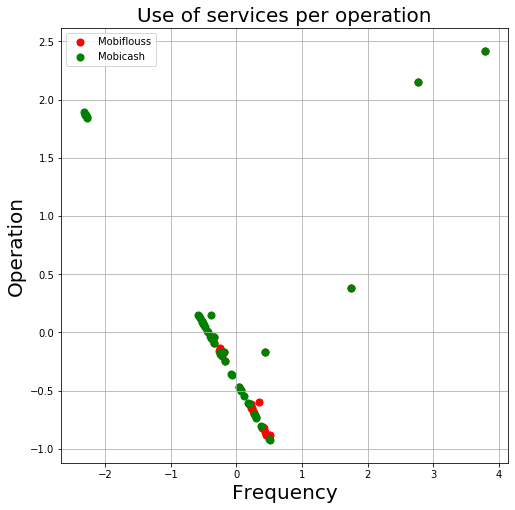

```python
fig = plt.figure(figsize = (8,8))
ax = fig.add_subplot(1,1,1)
ax.set_xlabel('Frequency', fontsize = 20)
ax.set_ylabel('Operation', fontsize = 20)
ax.set_title('Use of services per operation', fontsize = 20)
targets = ['Mobiflouss', 'Mobicash']
colors = ['r', 'g']
for target, color in zip(targets,colors):
    indicesToKeep = finalDf['Service'] == target
    ax.scatter(finalDf.loc[indicesToKeep, 'Frequency']
               , finalDf.loc[indicesToKeep, 'Operation']
               , c = color
               , s = 50)
ax.legend(targets)
ax.grid()
```

Les opérations sont fortement corrélées avec le service mobicash. Les clients utilisent fréquemment les opérations du service mobicash. Les opérations de mobiflouss sont faiblement utilisées.

```python
pca.explained_variance_ratio_
```

```
array([0.6125726, 0.3874274])
```

# 3/ SVM Method

```python
import pandas as pd
df = pd.read_csv('serviceUtiliseParOperation.csv')
df.head()
```

|  | Nombre | Service | IdOperation |
| --- | --- | --- | --- |
| 0 | 47064 | Mobicash | 1 |
| 1 | 3706 | Mobicash | 100 |
| 2 | 3703 | Mobicash | 101 |
| 3 | 1353 | Mobicash | 104 |
| 4 | 415071 | Mobicash | 105 |

```python
df['Service'].replace(['Mobicash', 'Mobiflouss'], [1, 2], inplace=True)
df.head()
```

|  | Nombre | Service | IdOperation |
| --- | --- | --- | --- |
| 0 | 47064 | 1 | 1 |
| 1 | 3706 | 1 | 100 |
| 2 | 3703 | 1 | 101 |
| 3 | 1353 | 1 | 104 |
| 4 | 415071 | 1 | 105 |

```python
from sklearn.model_selection import train_test_split
cible = df['Service']
features = df.drop(['Service'], axis=1)
X_train, X_test, y_train, y_test = train_test_split(features, cible, random_state = 0)
```

```python
from sklearn.svm import SVC, LinearSVC
svc = SVC(probability=True)
svc_model=svc.fit(X_train, y_train)
y_pred_svc1 = svc_model.predict(X_test)
```

```python
print('Accuracy of SVM classifier on training set:',svc_model.score(X_train, y_train))
print('Accuracy of SVM classifier on test set:', svc_model.score(X_test, y_test))
```

```
Accuracy of SVM classifier on training set: 0.7407407407407407
Accuracy of SVM classifier on test set: 0.42105263157894735
```

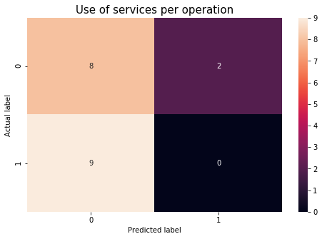

```python
cm = metrics.confusion_matrix(y_test, y_pred_svc1)
plt.figure(figsize=(8,5))
sns.heatmap(cm, annot=True, fmt="d");
plt.ylabel('Actual label');
plt.xlabel('Predicted label');

plt.title('Use of services per operation', size = 15);
```

```python
# Affichage du tableau d'évaluation (Precision,Recall, f1-score et support)
from sklearn.metrics import classification_report
print(classification_report(y_test, y_pred_svc1))
```

```
              precision    recall  f1-score   support

           1       0.47      0.80      0.59        10
           2       0.00      0.00      0.00         9

    accuracy                           0.42        19
   macro avg       0.24      0.40      0.30        19
weighted avg       0.25      0.42      0.31        19
```

# 3.1/ Polynomial SVM Method

## gamma ="auto"

```python
from sklearn.svm import SVC, LinearSVC
svc2 = SVC(kernel="poly",gamma='auto')
svc2_model=svc2.fit(X_train, y_train)
y_pred_svc2 = svc2_model.predict(X_test)
```

```python
print('Accuracy of SVM Poly classifier on training set:',svc2_model.score(X_train, y_train))
print('Accuracy of SVM Poly classifier on test set:', svc2_model.score(X_test, y_test))
```

```
Accuracy of SVM Poly classifier on training set: 0.2962962962962963
Accuracy of SVM Poly classifier on test set: 0.47368421052631576
```

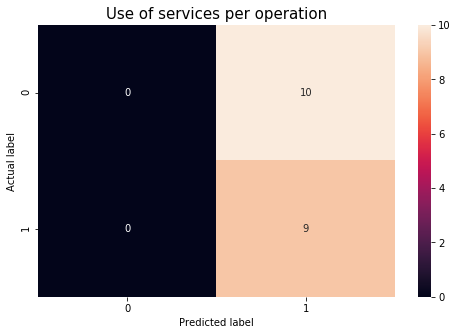

```python
cm = metrics.confusion_matrix(y_test, y_pred_svc2)
plt.figure(figsize=(8,5))
sns.heatmap(cm, annot=True, fmt="d");
plt.ylabel('Actual label');
plt.xlabel('Predicted label');

plt.title('Use of services per operation', size = 15);
```

```python
from sklearn.metrics import classification_report
print(classification_report(y_test, y_pred_svc2))
```

```
              precision    recall  f1-score   support

           1       0.00      0.00      0.00        10
           2       0.47      1.00      0.64         9

    accuracy                           0.47        19
   macro avg       0.24      0.50      0.32        19
weighted avg       0.22      0.47      0.30        19
```

On ne peut pas utiliser ce modele avec gamma="auto" parceque precision=0 , recall=0 et f1-score=0

## gamma ="scale"

```python
from sklearn.svm import SVC, LinearSVC
svc3 = SVC(kernel="poly",gamma='scale')
svc3_model=svc3.fit(X_train, y_train)
y_pred_svc3 = svc3_model.predict(X_test)
```

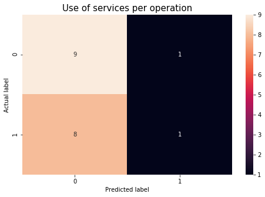

```python
cm = metrics.confusion_matrix(y_test, y_pred_svc3)
plt.figure(figsize=(8,5))
sns.heatmap(cm, annot=True, fmt="d");
plt.ylabel('Actual label');
plt.xlabel('Predicted label');

plt.title('Use of services per operation', size = 15);
```

```python
from sklearn.metrics import classification_report
print(classification_report(y_test, y_pred_svc3))
```

```
              precision    recall  f1-score   support

           1       0.53      0.90      0.67        10
           2       0.50      0.11      0.18         9

    accuracy                           0.53        19
   macro avg       0.51      0.51      0.42        19
weighted avg       0.52      0.53      0.44        19
```

# 4/ KNN Method

```python
import pandas as pd
df = pd.read_csv('serviceUtiliseParOperation.csv')
df.head()
```

|  | Nombre | Service | IdOperation |
| --- | --- | --- | --- |
| 0 | 47064 | Mobicash | 1 |
| 1 | 3706 | Mobicash | 100 |
| 2 | 3703 | Mobicash | 101 |
| 3 | 1353 | Mobicash | 104 |
| 4 | 415071 | Mobicash | 105 |

```python
df['Service'].replace(['Mobicash', 'Mobiflouss'], [1, 2], inplace=True)
df.head()
```

|  | Nombre | Service | IdOperation |
| --- | --- | --- | --- |
| 0 | 47064 | 1 | 1 |
| 1 | 3706 | 1 | 100 |
| 2 | 3703 | 1 | 101 |
| 3 | 1353 | 1 | 104 |
| 4 | 415071 | 1 | 105 |

```python
from sklearn.model_selection import train_test_split
cible = df['Service']
features = df.drop(['Service'], axis=1)
X_train, X_test, y_train, y_test = train_test_split(features, cible, random_state = 0)
```

```python
# Centrage et réduction
from sklearn.preprocessing import MinMaxScaler
scaler = MinMaxScaler()
X_train = scaler.fit_transform(X_train)
X_test = scaler.fit_transform(X_test)
```

```python
from sklearn.neighbors import KNeighborsClassifier
import numpy as np
# Choisir le meilleur k
error = []

for i in range(1, 40):
    knn = KNeighborsClassifier(i)
    knn_model = knn.fit(X_train, y_train)
    pred_i = knn_model.predict(X_test)
    error.append(np.mean(pred_i != y_test))
```

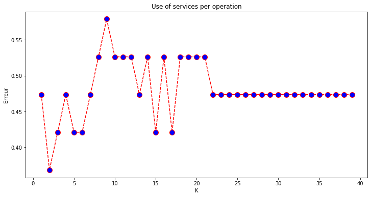

```python
plt.figure(figsize=(12, 6))
plt.plot(range(1, 40), error, color='red', linestyle='dashed', marker='o',
         markerfacecolor='blue', markersize=10)
plt.title('Use of services per operation')
plt.xlabel('K')
plt.ylabel('Erreur')
```

Pour trouver le k optimal, on va simplement tester le modèle pour tous les k de 1 à 40, mesurer l’erreur test et afficher la performance en fonction de k : Comme on peut le voir, le k-NN le plus performant est celui pour lequel k = 2. On connaît donc notre classifieur final optimal : 2, Ce qui veut dire que cest celui qui classifie le mieux les données.

```python
# Le meilleur k est 2
knn = KNeighborsClassifier(2)
knn_model = knn.fit(X_train, y_train)
y_pred_knn = knn_model.predict(X_test)
# Afficher le score de ce modèle
print('Accuracy of K-NN classifier on training set: {:.2f}'
     .format(knn.score(X_train, y_train)))
print('Accuracy of K-NN classifier on test set: {:.2f}'
     .format(knn.score(X_test, y_test)))
```

```
Accuracy of K-NN classifier on training set: 0.81
Accuracy of K-NN classifier on test set: 0.63
```

*Évaluation de l'algorithme Pour évaluer un algorithme, la matrice de confusion, la précision, le rappel et le score f1 sont les mesures les plus couramment utilisées. Les méthodes confusion_matrix et classification_report de sklearn.metrics peuvent être utilisées pour calculer ces métriques.

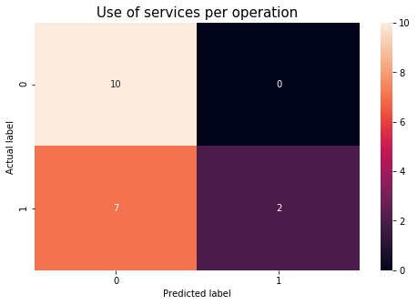

```python
cm = metrics.confusion_matrix(y_test, y_pred_knn)
plt.figure(figsize=(8,5))
sns.heatmap(cm, annot=True, fmt="d");
plt.ylabel('Actual label');
plt.xlabel('Predicted label');

plt.title('Use of services per operation', size = 15);
```

```python
# Affichage du tableau d'évaluation (Precision,Recall, f1-score et support)
from sklearn.metrics import classification_report
print(classification_report(y_test, y_pred_knn))
```

```
              precision    recall  f1-score   support

           1       0.59      1.00      0.74        10
           2       1.00      0.22      0.36         9

    accuracy                           0.63        19
   macro avg       0.79      0.61      0.55        19
weighted avg       0.78      0.63      0.56        19
```

Sensibilité = TP/(TP+FN) = 10/(10+7) = 0.59 Une sensibilité égale à 1 signifie que, lorsque les services est utilisée fréquemment par operation, il y a 59% de chance que le test de dépistage de l'utilisation soit positif. Spécificité = TN/(TN+FP) = 2/(2+0) = 1 Une spécificité est égale à 1 signifie que, lorsque les services n'est pas utilisée fréquemment par operation, il y 100% de chance que le test de dépistage de l'utilisation soit négatif.

TBC = (TP+TN)/Total = (10+2)/19 =0.63 L'algorithme K-NN permet de bien classifier les services selon leurs fréquences d’utilisation.

# 5/ Evaluation

# 5.1/ Comparative table

```python
# On va afficher un tableau qui ordonne les modèles du plus performant au moins performant suivant le score
acc_carte=accuracy_score(y_test_Crt, y_pred_crt)
acc_svc=accuracy_score(y_test, y_pred_svc1)
acc_svc_ploy=accuracy_score(y_test, y_pred_svc2)
acc_svc_scale=accuracy_score(y_test, y_pred_svc3)
acc_knn=accuracy_score(y_test, y_pred_knn)
models = pd.DataFrame({
    'Model': ['Decision Tree', 'Support Vector Machines', 'Support Vector Machines Polynomial(auto)',
              'Support Vector Machines Polynomial(scale)', 'KNN'
              ],
    'Score': [acc_carte, acc_svc, acc_svc_ploy,
              acc_svc_scale, acc_knn]})
models.sort_values(by="Score",ascending=False)
```

|  | Model | Score |
| --- | --- | --- |
| 0 | Decision Tree | 0.895067 |
| 4 | KNN | 0.631579 |
| 3 | Support Vector Machines Polynomial(scale) | 0.526316 |
| 2 | Support Vector Machines Polynomial(auto) | 0.473684 |
| 1 | Support Vector Machines | 0.421053 |

Notre analyse des les services les plus utilisés varie également selon les différents modèles testés. ce tableau comparatif montre que les valeurs numériques obtenues pour le score sont de 89%, 63%, 52%, 47% et 42% pour Decision Tree, KNN,SVM Polynomial Scale, SVM Polynomial Auto, SVM respectivement. Donc L'analyse comparative montre que les performances du modèle Decision Tree a la prédiction la plus correcte.

# 5.2/ Curve ROC

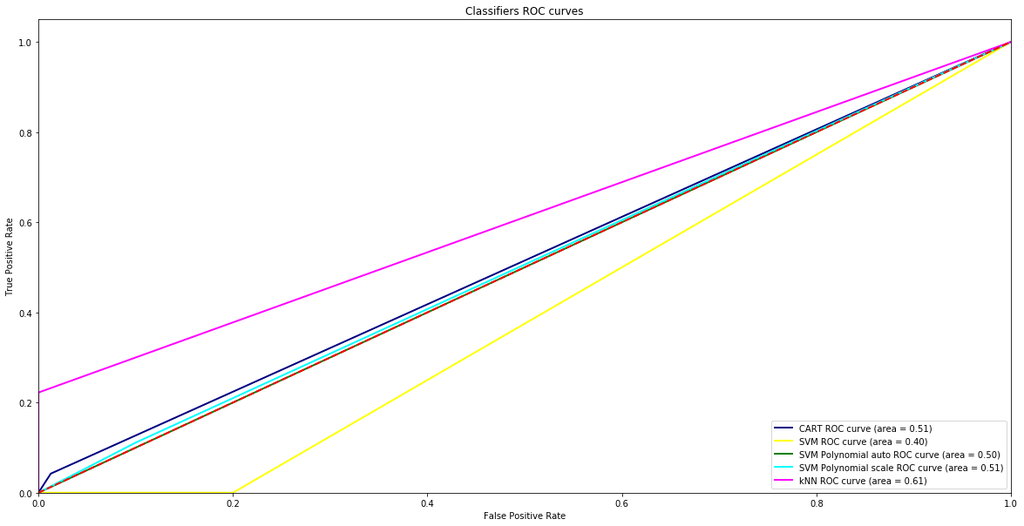

```python
#Affichage avec la bibliothèque graphique intégrée à Notebook
%matplotlib inline

from sklearn.metrics import roc_curve, auc

fpr1, tpr1, threshold1 = roc_curve(y_test_C, y_pred_crt, pos_label=2)
roc_auc1 = auc(fpr1, tpr1)
fpr2, tpr2, threshold2 = roc_curve(y_test, y_pred_svc1, pos_label=2)
roc_auc2 = auc(fpr2, tpr2)
fpr3, tpr3, threshold3 = roc_curve(y_test, y_pred_svc2, pos_label=2)
roc_auc3 = auc(fpr3, tpr3)
fpr4, tpr4, threshold4 = roc_curve(y_test, y_pred_svc3, pos_label=2)
roc_auc4 = auc(fpr4, tpr4)
fpr5, tpr5, threshold5 = roc_curve(y_test, y_pred_knn, pos_label=2)
roc_auc5 = auc(fpr5, tpr5)

plt.figure(figsize=(20,10))
plt.plot(fpr1, tpr1, color='navy', lw=2, label='CART ROC curve (area = %0.2f)'% roc_auc1)
plt.plot(fpr2, tpr2, color='yellow', lw=2, label='SVM ROC curve (area = %0.2f)'% roc_auc2)
plt.plot(fpr3, tpr3, color='green', lw=2, label='SVM Polynomial auto ROC curve (area = %0.2f)'% roc_auc3)
plt.plot(fpr4, tpr4, color='cyan', lw=2, label='SVM Polynomial scale ROC curve (area = %0.2f)'% roc_auc4)
plt.plot(fpr5, tpr5, color='magenta', lw=2, label='kNN ROC curve (area = %0.2f)'% roc_auc5)

plt.plot([0, 1], [0, 1], color='red', lw=2, linestyle='--')
plt.xlim([0.0, 1.0])
plt.ylim([0.0, 1.05])
plt.xlabel('False Positive Rate')
plt.ylabel('True Positive Rate')
plt.title('Classifiers ROC curves')
plt.legend(loc = "lower right")
plt.show()
```

Dans cette figure ou courbe ROC AUC = 0.5 Symbolisée par la diagonale principale dans le graphique (courbe avec la couleur rouge découpe) La courbe de KNN ROC curve (coloré en rose) est toujours « au-dessus» de celle de toutes les autres courbes : elle est meilleur que les methodes de CART =>Donc la courbe de KNN ROC serait un meilleur modèle de prédiction pour notre objectif(les services les plus utilisés)